# Predictive Quality Modeling in Semiconductor Manufacturing

Sunday, January 25, 2015

## Introduction

In many modern manufacturing settings, the amount of data being generated makes univariate SPC methods impractical.

This presentation explores the use of machine learning algorithms to identify semiconductor lots with low yields.

The dataset comes from the [UCI Machine Learning Repository](https://archive.ics.uci.edu/ml/datasets/SECOM).

## Methodology

- Split data into training and test sets
- Pre-processing the data to remove missing values and reduce feature set
- Tune models on training data set
- Compare results of best models from training on the held out test set

## Split Data

- The data set contains 1567 semiconductor wafer batches with 590 features
- Each batch is given a binary classification of acceptable or not based on yield
- There are only 104 failures in the entire dataset
- There are a total of 41951 missing values
- Split the data into training and test sets (70%/30%)

## Pre-processing

- The test set is put to the side for now
- Remove zero and near zero variance features (n=127)
- Remove features where more than 20% of values are missing (n=32)
- Center and scale each feature to mean of 0 and variance of 1
- Impute missing data using k-nearest neighbors (k=5)
- Feature selection using PCA, ICA and Chi-Squared (n=60)

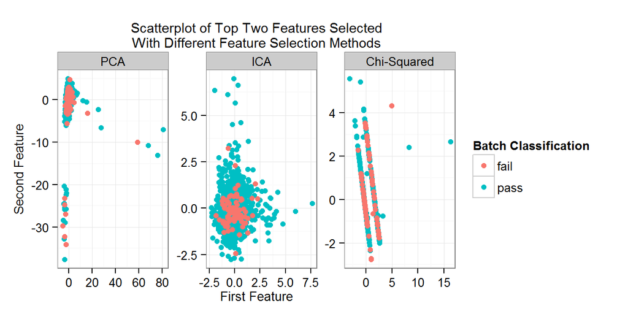

## Feature Selection Continued

Heat Maps of Correlation Matrix By Feature Selection Method

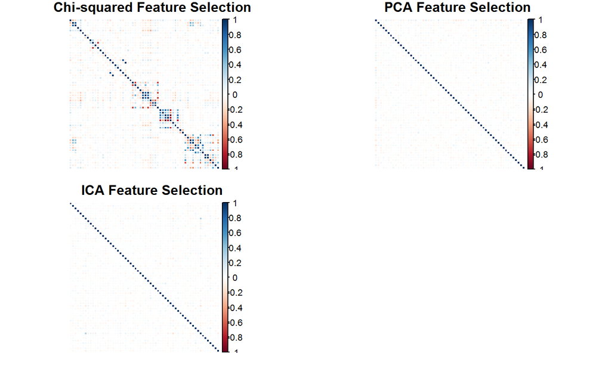

## Model Selection

We attempted to build a prediction model using the following four algorithms:

- [Decision Tree](http://cran.r-project.org/web/packages/rpart/rpart.pdf)
- [Random Forest](http://cran.r-project.org/web/packages/randomForest/randomForest.pdf)
- [Naive Bayes](http://cran.r-project.org/web/packages/klaR/klaR.pdf)
- [Stochastic Gradiant Boosting](http://cran.r-project.org/web/packages/gbm/gbm.pdf)

Additionally these models were fit using repeated cross validation (5-fold, 10 times) and with three feature selection methods and the full data set after centering, scaling, imputing missing values.

Due to high computational times required to train the Random Forest and Naive Bayes, these models were not fit with the full dataset.

## Training

- The models were tuned with the relevant tuning parameters for each algorithm
- Sensitivity was used as the tuning metric versus accuracy or ROC due to high class imbalance.
- One model per combination of feature set and algorithm was chosen for evaluation against the test set.

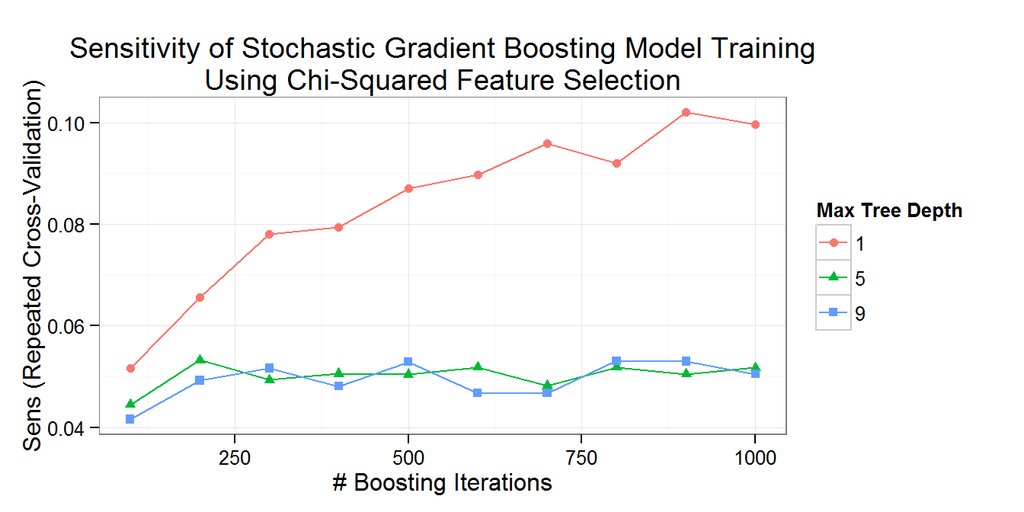

## Model Comparison

- Naive Bayes with Chi-squared FS had the highest sensitivity but the lowest specificity
- None of the models had accuracy rates that were significantly better than the No Information Rate

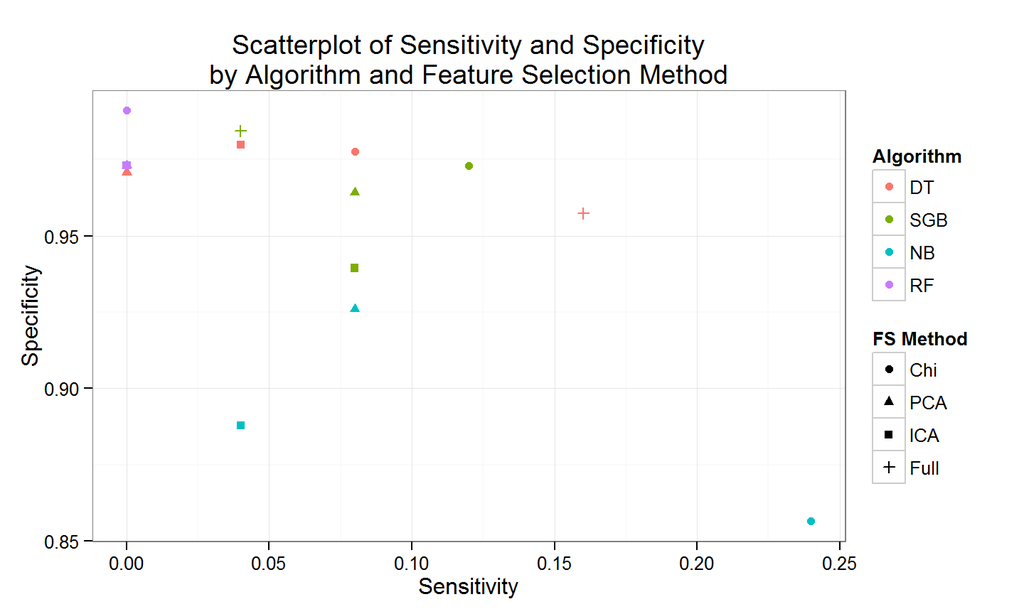

## Conclusions and Next Steps

- The results highlight common issues with fault detection in manufacturing of complex systems/processes
  - High Feature Counts
  - Low Observation Counts
  - Trade-offs between Type 1 and Type 2 Error
- Explore alternative feature selection methods (e.g. Information Gain)
- Artifically inflate number of batch failures in training set to improve ability of classification algorithms
- Compare to multivariate SPC models (e.g. T<sup>2</sup>, MEWMA)